# `Lesson 01` Product Strategy

#### Tags

- Title: Introduction to Product Management
- Date: 29/03/2022
- Course: Product Manager Nanodegree
  - Instructor: Alex King
  - COD: ND036

## Class Notation

### 1. Instructor Intro

Instructor name is **Alex King**.

Alex King is currently a Product Manager (PM) at Uber, and before it, he has worked at Google for eight years.

He graduated in Informatics at Washington University. Informatics is a combination of computer science, business, and design.

### 2. What is Product Management?

> At its core, product management is really about **identifying & defining problems**.

Product Manager must have:

- Deep understanding of problems facing user;
- Understand user needs;
- Know their product, and;
- Know the competition.

To do this Product Manager has to answer lots of questions.

Some questions PM must be aware of answering:

- What are we building?
- Who are we building it for?
- Why are we building this?
- When are we building this?

#### What are we building?

- WHAT the product does?

The PM is in charge to define what the team gonna build, specifically what the product **should do**.

- What do the people WANT the product to do?

The PM must be aware of what the people want and what will **create value** for the user of this product.

#### Who are we building it for?

- WHO is your user?

The PM must know its audience, which means PM must understand who will use its products. It is also critical to building great products.

- WHAT are their needs?

Different types of users will have different needs. So it is mandatory to understand their needs on a very deep level.

##### EXAMPLE - Calculator for different Users

Two different audiences with different needs:

- Grade School: Demand basic math operations.
- Scientist working on Pharmaceutical Development: Complex math operations.

#### Why are we building this?

This question could also be split into:

> WHY are we solving this problem? WHY are we building this specific solution?

To answer those questions, PM should focus on identifying:

- WHAT is the impact?

The PM must identify and understand solving a problem need to have both value and meet business objective.

- WHY this solution?

The PM needs to explain to its team why to opt for one solution over the others. Giving a compelling answer will motivate the entire team to make it possible.

#### When are we building this?

The PM must prioritize the tasks and activities because usually, it is impossible for everything to build all at once.

So it is crucial to prioritize what should be built first and what will be developed later. There are always going to be tradeoffs to be made.

> **NOTE:** PM has no concern to answer HOW it will be built?

#### Skills of a PM

- Creating Strategy

The PM must be hyperaware of User needs and have intuition about how the user will respond to new features or changes in the product.

Also, PM needs to map out the steps through the complete product potential and vision.

In addition, the PM must be able to course-correct as they learn new information.

- Communicating

The PM needs to communicate across various audiences (Engineer Team, Development Team, IT Team, Support Team, Executives, Customers, Users, etc.).

The ability to translate what each audience wants, and explain it to DevOps Team, Executive Team, etc. In other words, the PM works as a glue between those audiences.

- Coordinating

With this end-to-end visibility, PM must connect people across the teams and share information to solve/facilitate problems and reach shared goals and objectives.

- Responding to new info

The PM is in charge of deciding what to do with this new information: a competitor launching a new product, an important email from a CEO, etc.

- Dealing with fires

PM should be in charge to solving unexpected problems.

### 3. Why PM is important?

In this lesson, Alex has explained the importance of PM.

Why Product Management Matters?

- Bringing products to market is way more complicated than ever; > It is **super easy** to develop a new product that **fails**, but it is **very difficult** to build a **great product**.
- Need someone to focus on the user and the problem; > The PM is in charge of keeping the team focused on what really matters.
  - Someone to orchestrate - Get the team moving in the same direction; > The PM also plays an important role aligning all of the other teams that are working on the product.

As mentioned in the last lesson, one of the most critical tasks performed by PM is to identify and define what problem that teams should solve.

Solving a problem itself is not a problem but identifying the right problem to be solved is a challenging task.

> It’s important to make sure that you’re solving the right problem.

#### Real Problem (for real users)

The PM must focus on solving real problems for real users.

Google Glasses is an example of a failed product. The Google Develop Team has miniaturized a cellphone into a Glasses, but this new device does not solve any real problems of real users.

It is unclear what Google Glasses is solving and why anyone needs it.

#### Creating Value (for users and the company)

The PM should be aware of building products that create value for the user and the company. In this case, the user will find enough value to “pay” to have it. Remember that “pay” could be money or indirectly when you watch an advertisement.

A common pitfall here is to build a product that creates value for a niche (very very very small) group of users.

The PM must be aware not to be influenced by your own personal needs.

> People will build things that they want. But, often, the product that gets made does not solve a need for enough people to create a **viable business**.

#### PM acts as a hub

The PM plays an important role in connecting and aligning all the relevant teams needed to build and launch a product:

- The PM advocates for the users;
- Understand the business;
- Empower design;
- Creates stability for engineers;
- Motivates all teams involved in the product, and;
- Keep the teams working together and focused in the same direction.

##### EXAMPLES

- Good Product Management
  - WhatsApp
  - OpenTable
  - Headspace
- Bad Product Management
  - MoviePass: Not sustainable Business Model (Fee reducing)
  - everpix: Small user base, they do not invest in Growth and marketing (Which could lead to not differentiating its products from the free competitors.)
  - Google Wave: Lack of clarity about the product’s purpose. The product is too complex.

> A way to measure whether the product is too complex is if you can not explain what it does in a couple of sentences.

### 4. A quick history of Product Management

It is difficult to determine when and how Product Management came into being. However, Alex has pointed out some important milestones.

#### 1931 - Neil McElroy and “Brand Men”

> Neil McElroy wrote a memo called “Brand Men” to hire some additional people on his team while at Procter & Gamble. This memo touched on two parts of this new role that carried into product management:
> - “Full responsibility” - Product managers are responsible for the success of their product. They need to work across multiple teams in order to achieve their goals and build great products.
> - **“Studying things personally firsthand through field testing”** - Getting out of the building, seeing problems first hand, and interacting with users is a critical part of the product management role. This experience will provide you with deep insights and build empathy for your users.

#### 1930s - Bill Hewlett and David Packard

> These two entrepreneurs met while at Stanford. **McElroy** was an advisor of theirs and they were deeply influenced by him. They went on to found Hewlett-Packard in 1939. And **one of HP’s key strategies was to put decision making as close to the customer as possible**. Being close to your customers and understanding their needs is a core part of product management.

#### 1960s - Japan

> After World War II, just-in-time manufacturing became common in Japan. In addition to reducing waste during the production process, there were also **two important principles**:
> 1. Kaizen: change for better - **continuously improving** the business while always driving for innovation and evolution. Today you see Product Managers driving constant improvements and optimizations for their products.
> 2. Genchi genbutsu - real location, real thing - This means **going to the source to find the facts to make correct decisions**. This is again, highlighting the importance for Product Managers to get out of the building and experience everything first hand.

> Product Managers originally started in the marketing function and focused on making sure the product is in the right place, at the right price, with the right promotion. As tech began to create giant new industries, it became crucial that products were developed to more deeply meet user needs.

#### 4 P’s of Marketing

- Product;
- Place;
- Price, and;
- Promotion.

> Ensuring the product is at the right place at the right price and the right promotion.

The management of these 4 P’s is divided into two:

- The focus on the right place, the right price, and the right promotion are the so-called **Brand Management**, and;
- The focus on the right product is the so-called **Product Management**.

Because of the new challenges of creating products to solve a real problem (meet customer needs) and considering new project management techniques, like Agile Methodologies, the PM came to focus more on what the user wants and what the product must do to solve it.

It is not a rule, so there are companies with place, price, and promotion on the PM chores (shared responsability with Marketing Team).

[Reference 1 - The evolving role of product management](https://www.oreilly.com/radar/the-evolving-role-of-product-management/)

### 5. Overview of Course & Learning Objectives

This Course Part consists of 5 lessons:

1. Introduction to Product Management (Current)
2. Role of a Product Manager
3. Finding the Right Problem
4. Vision and Strategy
5. Communication Skills

#### Role of Product Manager

Will cover:

- What Product Managers DO;
- Who they work with, and;
- Artifacts that PM creates (like roadmaps and PRD’s).

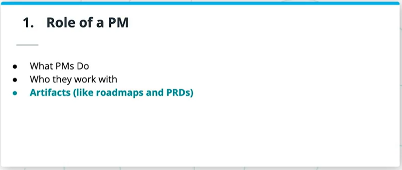

#### Finding the Right Problem

Will cover:

- Dig into Identify the right opportunities;
- Understand the market, user, and problem, and;
- Create hypotheses and test them.

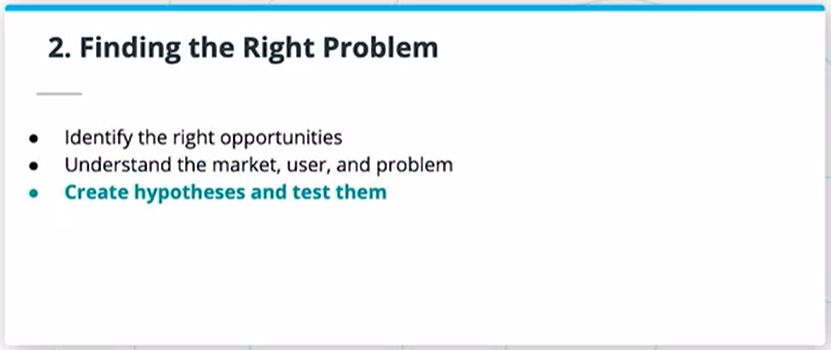

#### Vision and Strategy

Will cover:

- Deep understanding of Vision & Strategy;
- MVP (Minimum Viable Products), and;
- Different Business Models.

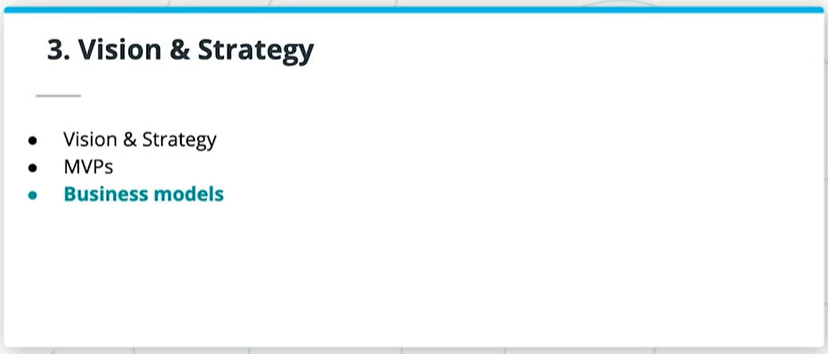

#### Communication Skills

Will cover:

- Effective Communication;
- How to use Storytelling to estabilish powerful visions, and;
- Building compelling presentations.

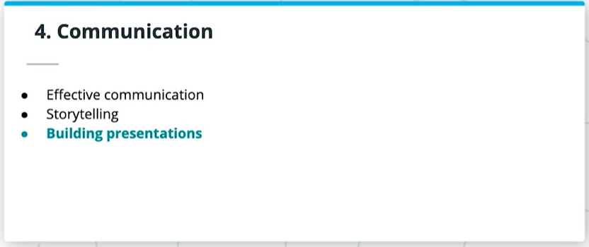

#### Learning Objectives

> - Describe the role of a PM and a PM’s critical partners
> - Build roadmaps and write PRDs
> - Identify and size opportunities
> - Create a business case for a new product opportunity
> - Define the use cases of a product, including its KPIs
> - Build a projected revenue model for your new product
> - Put together and present a compelling product pitch to gain internal stakeholder buy-in

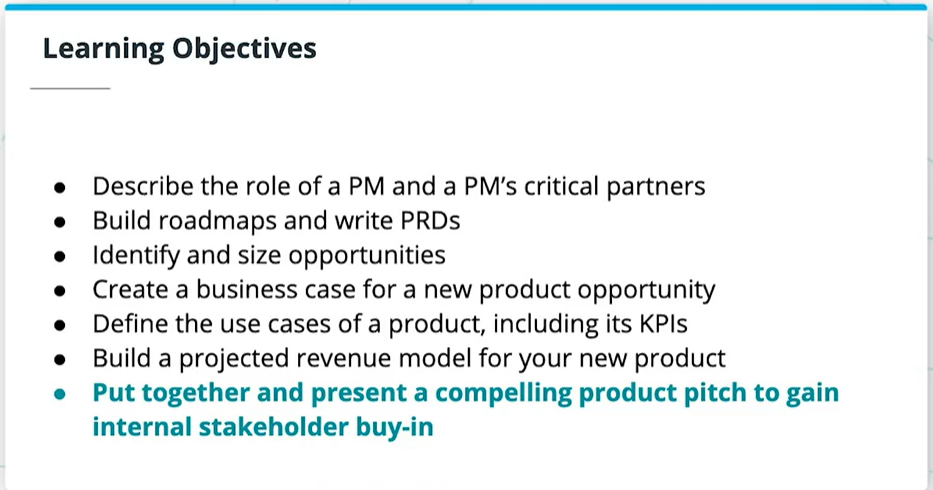